# Kira Plastinina’s customer-cluster analysis

Edwin Mutuma

7/10/2021

# PROBLEM DEFINITION

## **a) Specifying the Question**

Kira Plastinina is a Russian brand whose sales and Marketing team would like to understand their customer’s behavior from data that they have collected over the past year.

## **b) Defining the metrics for success**

Draw insights from the cluster analysis performed on the data

## **c) Understanding the context**

Kira Plastinina is a Russian fashion designer whose brand is sold through a defunct chain of retail stores in Russia, Ukraine, Kazakhstan, Belarus, China, Philippines, and Armenia. The marketing team wants an analysis carried out on their customers and insights drawn from various attributes and features of their customers.

## **d) Recording the Experimental Design**

- Define the question, the metric for success, the context, experimental design taken.
- Read and explore the given dataset.
- Find and deal with outliers, anomalies, and missing data within the dataset.
- Perform univariate and bivariate analysis.
- Perform clustering stating insights drawn from your analysis and visualizations.

## **e) Relevance of the data**

The data presented was relevant and useful in performing cluster analysis

```r
library(dplyr)
```

```r
library(ggplot2)
```

## Importing data

```r
# importing our data
# reading our data
kp <- read.csv('http://bit.ly/EcommerceCustomersDataset')
```

## Previewing the data

```r
# Previewing the top 6 entries
head(kp)
```

```
##   Administrative Administrative_Duration Informational Informational_Duration
## 1              0                       0             0                      0
## 2              0                       0             0                      0
## 3              0                      -1             0                     -1
## 4              0                       0             0                      0
## 5              0                       0             0                      0
## 6              0                       0             0                      0
##   ProductRelated ProductRelated_Duration BounceRates ExitRates PageValues
## 1              1                0.000000  0.20000000 0.2000000          0
## 2              2               64.000000  0.00000000 0.1000000          0
## 3              1               -1.000000  0.20000000 0.2000000          0
## 4              2                2.666667  0.05000000 0.1400000          0
## 5             10              627.500000  0.02000000 0.0500000          0
## 6             19              154.216667  0.01578947 0.0245614          0
##   SpecialDay Month OperatingSystems Browser Region TrafficType
## 1          0   Feb                1       1      1           1
## 2          0   Feb                2       2      1           2
## 3          0   Feb                4       1      9           3
## 4          0   Feb                3       2      2           4
## 5          0   Feb                3       3      1           4
## 6          0   Feb                2       2      1           3
##         VisitorType Weekend Revenue
## 1 Returning_Visitor   FALSE   FALSE
## 2 Returning_Visitor   FALSE   FALSE
## 3 Returning_Visitor   FALSE   FALSE
## 4 Returning_Visitor   FALSE   FALSE
## 5 Returning_Visitor    TRUE   FALSE
## 6 Returning_Visitor   FALSE   FALSE
```

```r
# Previewing the datatypes of our columns
lapply(kp,class)
```

```
## $Administrative
## [1] "integer"
##
## $Administrative_Duration
## [1] "numeric"
##
## $Informational
## [1] "integer"
##
## $Informational_Duration
## [1] "numeric"
##
## $ProductRelated
## [1] "integer"
##
## $ProductRelated_Duration
## [1] "numeric"
##
## $BounceRates
## [1] "numeric"
##
## $ExitRates
## [1] "numeric"
##
## $PageValues
## [1] "numeric"
##
## $SpecialDay
## [1] "numeric"
##
## $Month
## [1] "character"
##
## $OperatingSystems
## [1] "integer"
##
## $Browser
## [1] "integer"
##
## $Region
## [1] "integer"
##
## $TrafficType
## [1] "integer"
##
## $VisitorType
## [1] "character"
##
## $Weekend
## [1] "logical"
##
## $Revenue
## [1] "logical"
```

```r
# Checking the shape of the dataset
dim(kp)
```

```
## [1] 12330    18
```

```r
# Checking the structure of the data we have
str(kp)
```

```
## 'data.frame':    12330 obs. of  18 variables:
##  $ Administrative         : int  0 0 0 0 0 0 0 1 0 0 ...
##  $ Administrative_Duration: num  0 0 -1 0 0 0 -1 -1 0 0 ...
##  $ Informational          : int  0 0 0 0 0 0 0 0 0 0 ...
##  $ Informational_Duration : num  0 0 -1 0 0 0 -1 -1 0 0 ...
##  $ ProductRelated         : int  1 2 1 2 10 19 1 1 2 3 ...
##  $ ProductRelated_Duration: num  0 64 -1 2.67 627.5 ...
##  $ BounceRates            : num  0.2 0 0.2 0.05 0.02 ...
##  $ ExitRates              : num  0.2 0.1 0.2 0.14 0.05 ...
##  $ PageValues             : num  0 0 0 0 0 0 0 0 0 0 ...
##  $ SpecialDay             : num  0 0 0 0 0 0 0.4 0 0.8 0.4 ...
##  $ Month                  : chr  "Feb" "Feb" "Feb" "Feb" ...
##  $ OperatingSystems       : int  1 2 4 3 3 2 2 1 2 2 ...
##  $ Browser                : int  1 2 1 2 3 2 4 2 2 4 ...
##  $ Region                 : int  1 1 9 2 1 1 3 1 2 1 ...
##  $ TrafficType            : int  1 2 3 4 4 3 3 5 3 2 ...
##  $ VisitorType            : chr  "Returning_Visitor" "Returning_Visitor" "Returning_Visitor" "Returning_Visitor" ...
##  $ Weekend                : logi  FALSE FALSE FALSE FALSE TRUE FALSE ...
##  $ Revenue                : logi  FALSE FALSE FALSE FALSE FALSE FALSE ...
```

## Data Cleaning

```r
# Checking for null values in the data
colSums(is.na(kp))
```

```
##          Administrative Administrative_Duration           Informational
##                      14                      14                      14
##  Informational_Duration          ProductRelated ProductRelated_Duration
##                      14                      14                      14
##             BounceRates               ExitRates              PageValues
##                      14                      14                       0
##              SpecialDay                   Month        OperatingSystems
##                       0                       0                       0
##                 Browser                  Region             TrafficType
##                       0                       0                       0
##             VisitorType                 Weekend                 Revenue
##                       0                       0                       0
```

```r
#Dropping the rows with the null values
kp <- na.omit(kp)

# Checking to ensure none are left
sum(is.na(kp))
```

```
## [1] 0
```

```r
# Checking for whether we have any duplicate rows in the dataset
sum(duplicated(kp))
```

```
## [1] 117
```

```r
# Dealing with the duplicates
kp <- distinct(kp)
sum(duplicated(kp))
```

```
## [1] 0
```

```r
# Checking the shape of the dataset
dim(kp)
```

```
## [1] 12199    18
```

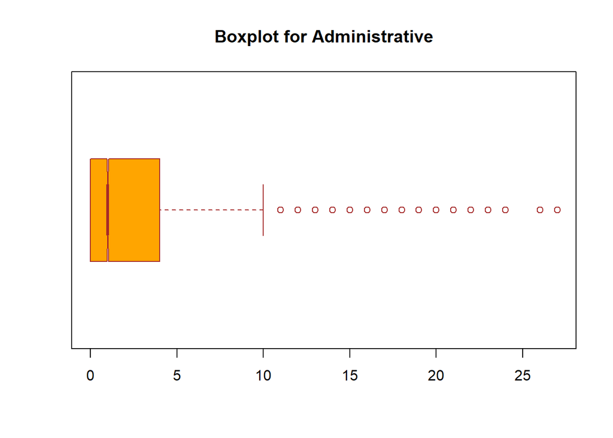

```r
boxplot(kp$Administrative,
        main="Boxplot for Administrative",
        col = "orange",
        border="brown",
        horizontal=T,
        notch=T)
```

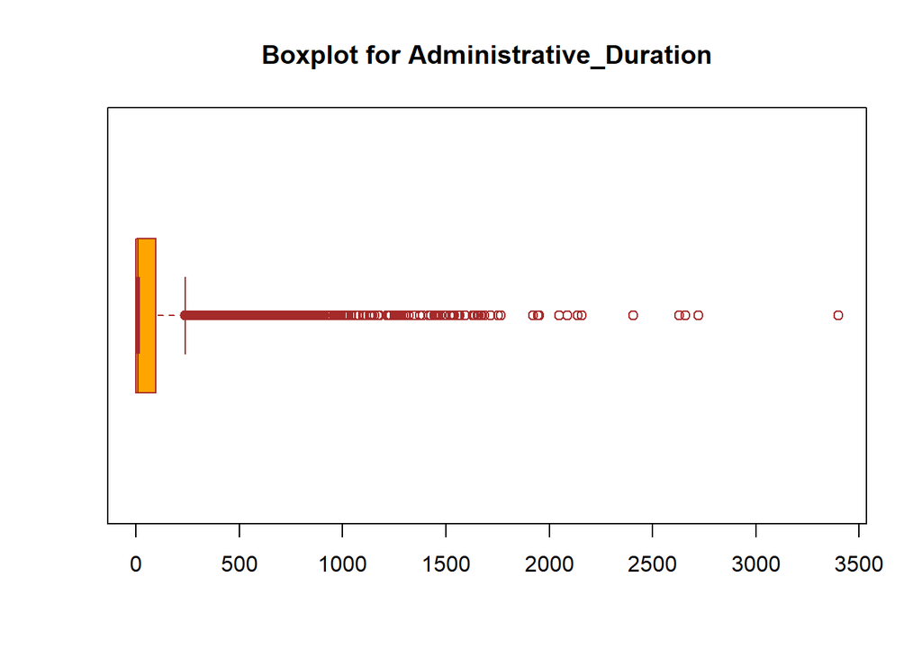

```r
boxplot(kp$Administrative_Duration,
        main="Boxplot for Administrative_Duration",
        col = "orange",
        border="brown",
        horizontal=T,
        notch=T)
```

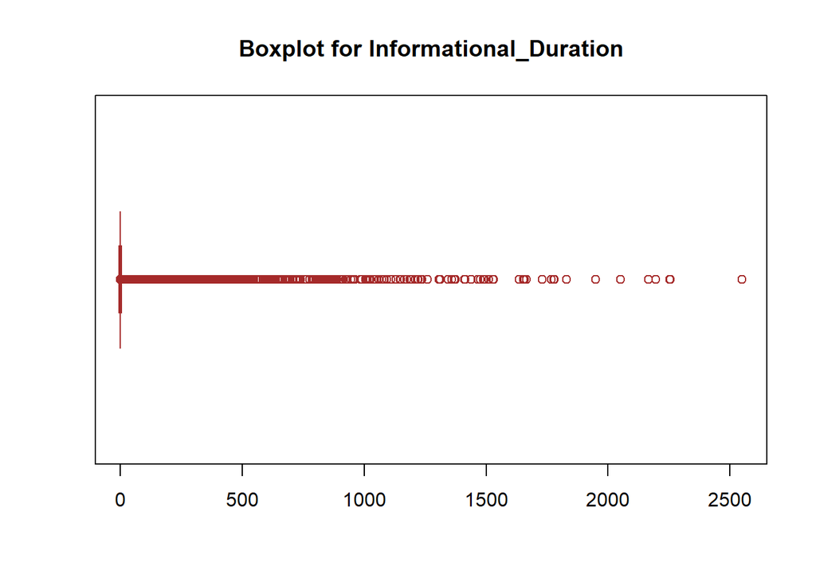

```r
boxplot(kp$Informational_Duration,
        main="Boxplot for Informational_Duration",
        col = "orange",
        border="brown",
        horizontal=T,
        notch=T)
```

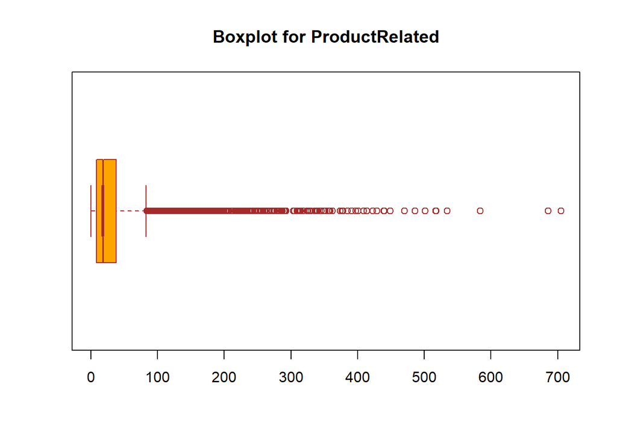

```r
boxplot(kp$ProductRelated,
        main="Boxplot for ProductRelated",
        col = "orange",
        border="brown",
        horizontal=T,
        notch=T)
```

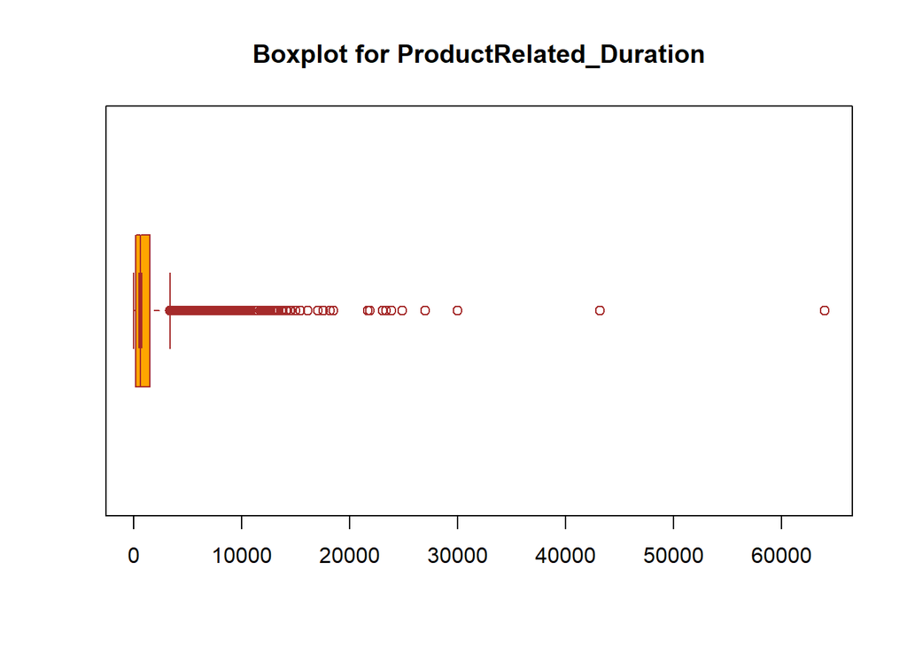

```r
boxplot(kp$ProductRelated_Duration,
        main="Boxplot for ProductRelated_Duration",
        col = "orange",
        border="brown",
        horizontal=T,
        notch=T)
```

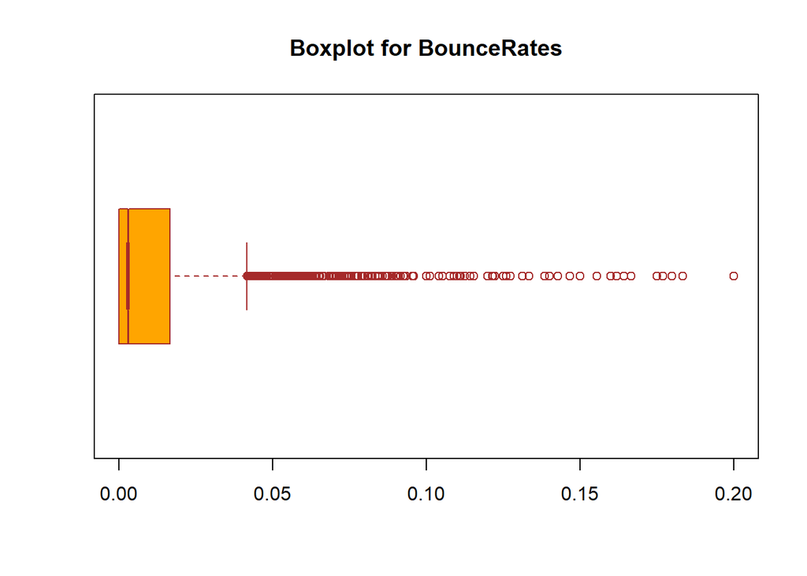

```r
boxplot(kp$BounceRates,
        main="Boxplot for BounceRates",
        col = "orange",
        border="brown",
        horizontal=T,
        notch=T)
```

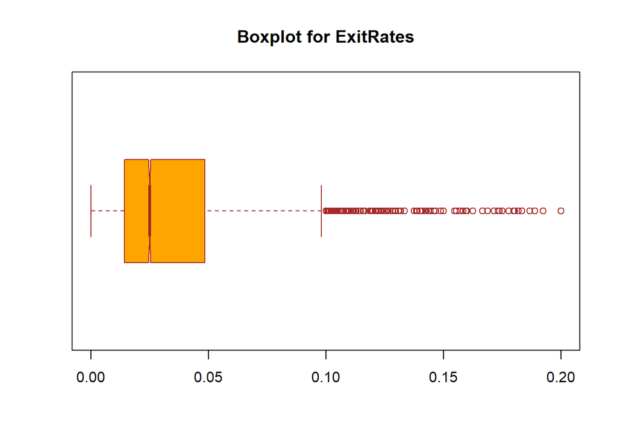

```r
boxplot(kp$ExitRates,
        main="Boxplot for ExitRates",
        col = "orange",
        border="brown",
        horizontal=T,
        notch=T)
```

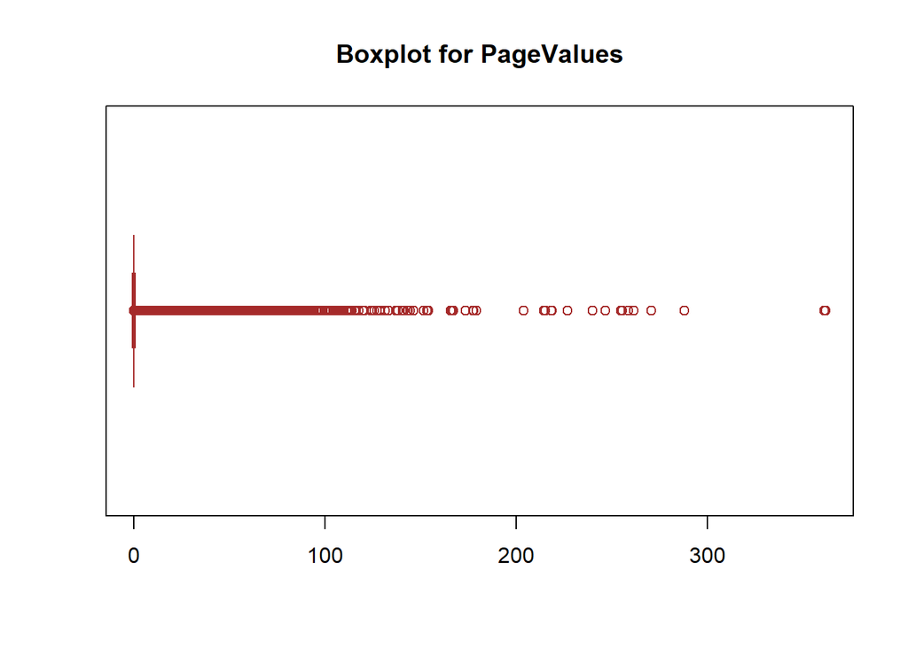

```r
boxplot(kp$PageValues,
        main="Boxplot for PageValues",
        col = "orange",
        border="brown",
        horizontal=T,
        notch=T)
```

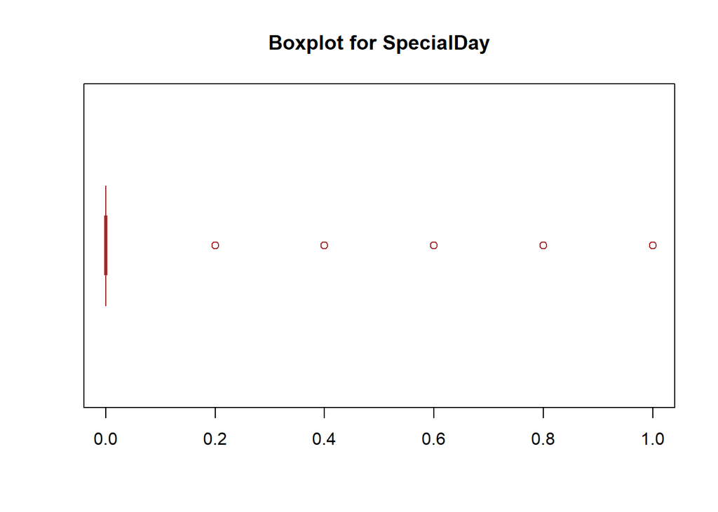

```r
boxplot(kp$SpecialDay,
        main="Boxplot for SpecialDay",
        col = "orange",
        border="brown",
        horizontal=T,
        notch=T)
```

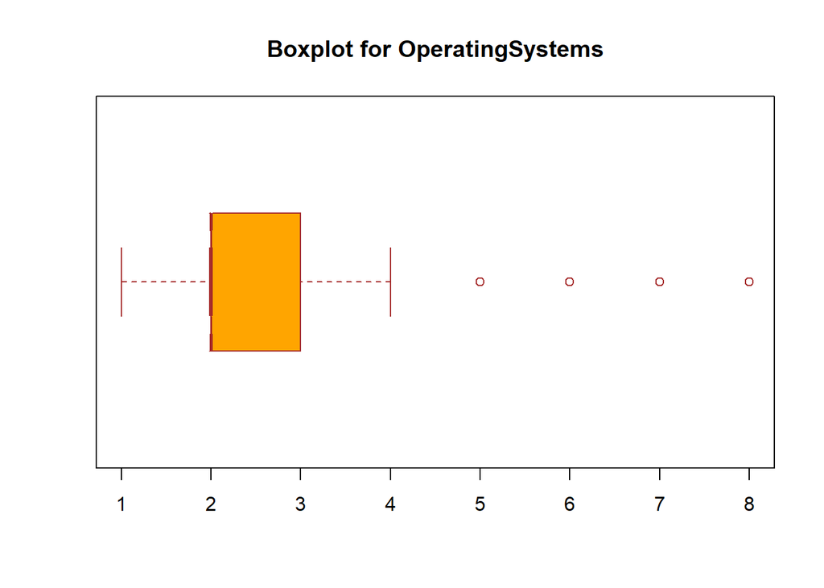

```r
boxplot(kp$OperatingSystems,
        main="Boxplot for OperatingSystems",
        col = "orange",
        border="brown",
        horizontal=T,
        notch=T)
```

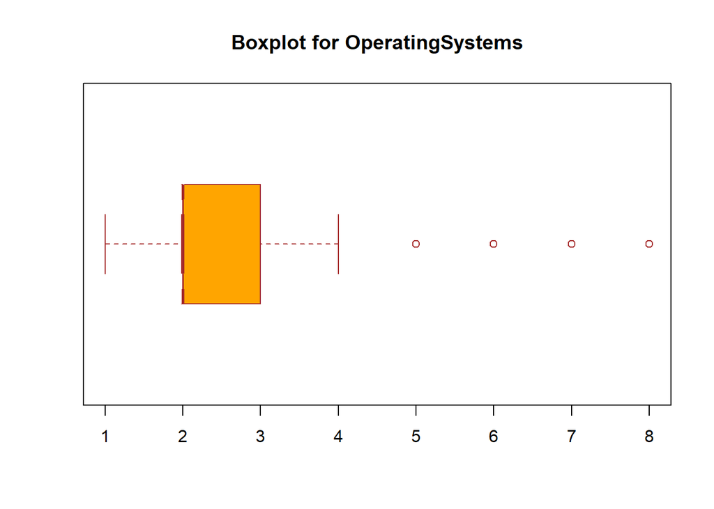

```r
boxplot(kp$OperatingSystems,main="Boxplot for OperatingSystems",col = "orange", border="brown", horizontal=T, notch=T)
```

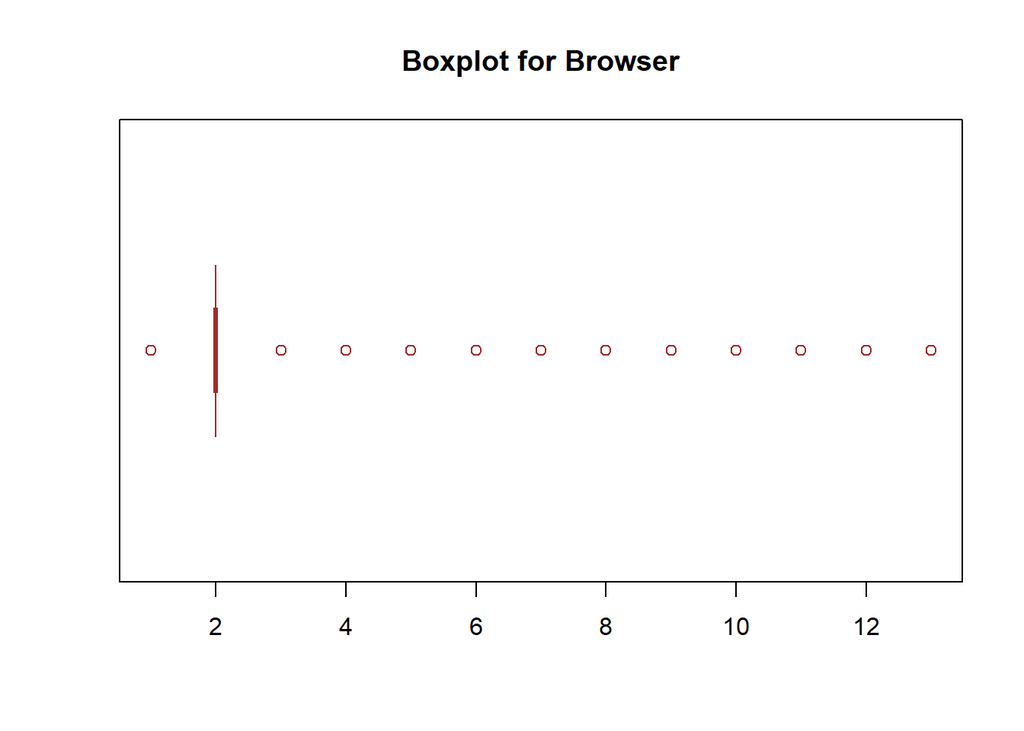

```r
boxplot(kp$Browser,
        main="Boxplot for Browser",
        col = "orange",
        border="brown",
        horizontal=T,
        notch=T)
```

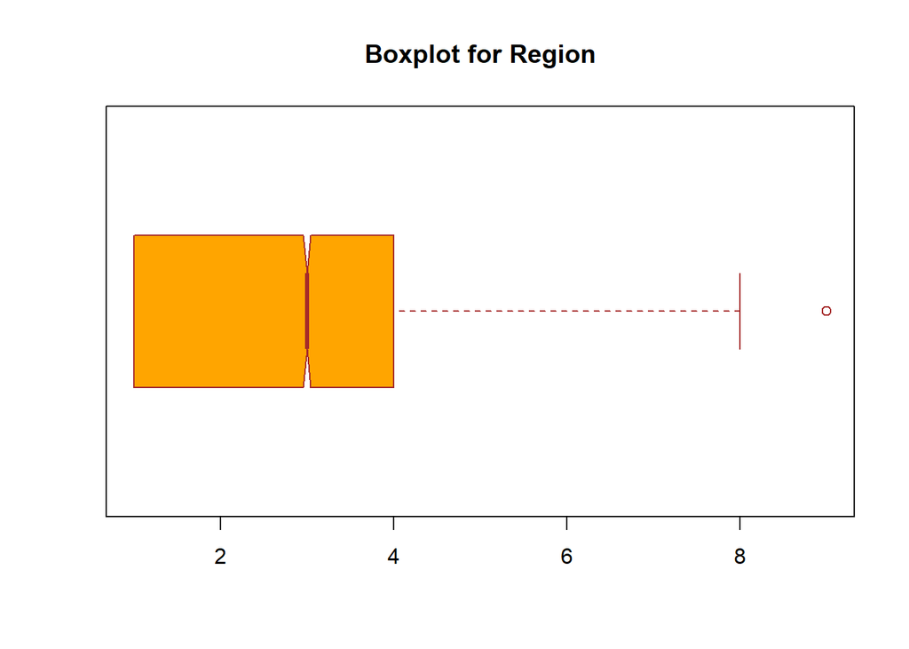

```r
boxplot(kp$Region,
        main="Boxplot for Region",
        col = "orange",
        border="brown",
        horizontal=T,
        notch=T)
```

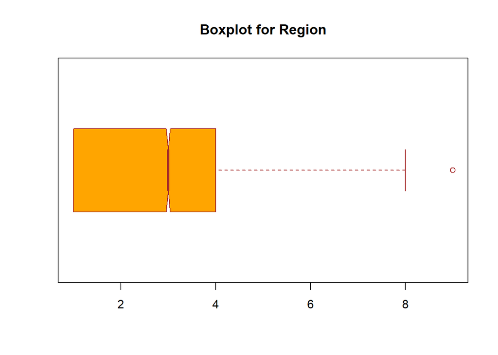

```r
boxplot(kp$Region,
        main="Boxplot for Region",
        col = "orange",
        border="brown",
        horizontal=T,
        notch=T)
```

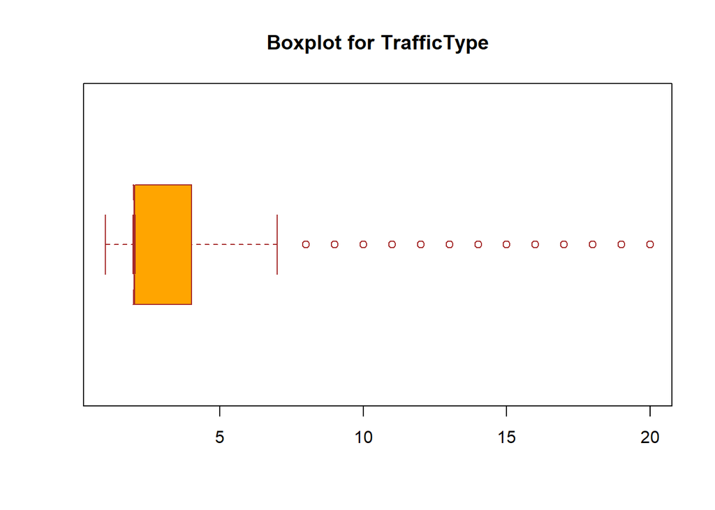

```r
boxplot(kp$TrafficType,main="Boxplot for TrafficType",col = "orange", border="brown", horizontal=T, notch=T)
```

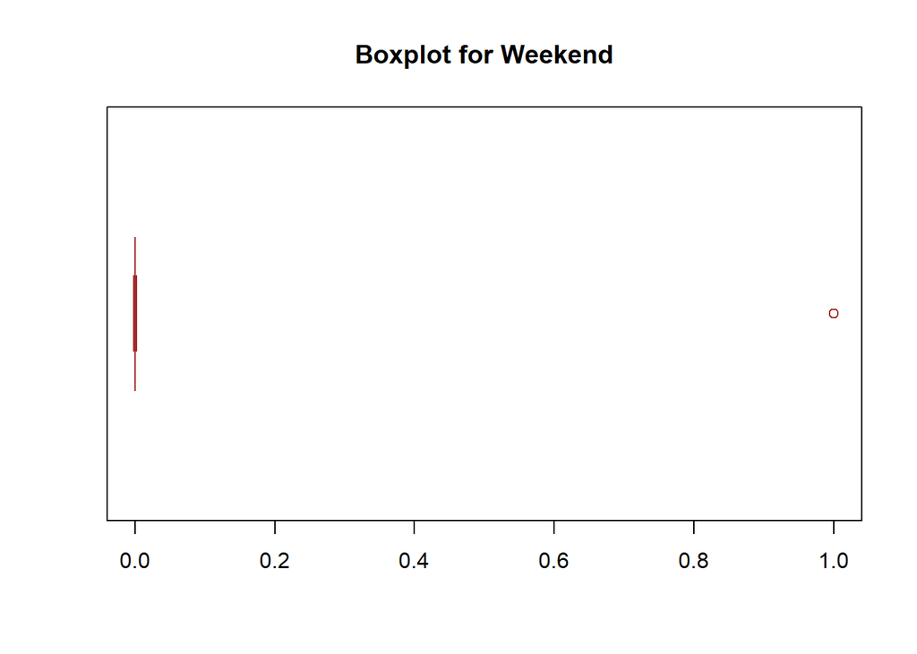

```r
boxplot(kp$Weekend,
        main="Boxplot for Weekend",
        col = "orange",
        border="brown",
        horizontal=T,
        notch=T)
```

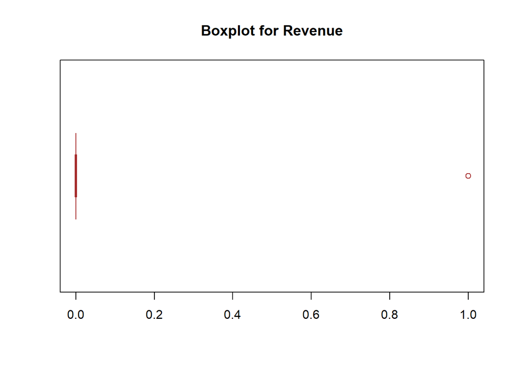

```r
boxplot(kp$Revenue,
        main="Boxplot for Revenue",
        col = "orange",
        border="brown",
        horizontal=T,
        notch=T)
```

## Exploratory Data Analysis

```r
# Mean of various columns
mean <- colMeans(kp[sapply(kp, is.numeric)])
mean
```

```
##          Administrative Administrative_Duration           Informational
##            2.340028e+00            8.168214e+01            5.088122e-01
##  Informational_Duration          ProductRelated ProductRelated_Duration
##            3.483734e+01            3.205845e+01            1.207508e+03
##             BounceRates               ExitRates              PageValues
##            2.044674e-02            4.149678e-02            5.952500e+00
##              SpecialDay        OperatingSystems                 Browser
##            6.197229e-02            2.124354e+00            2.358144e+00
##                  Region             TrafficType
##            3.153291e+00            4.074596e+00
```

```r
# Median
library(robustbase)
library(tidyverse)
median <- kp%>%
  select_if(is.numeric) %>%
  as.matrix()%>%
  colMedians()
print(median)
```

```
##          Administrative Administrative_Duration           Informational
##            1.000000e+00            9.000000e+00            0.000000e+00
##  Informational_Duration          ProductRelated ProductRelated_Duration
##            0.000000e+00            1.800000e+01            6.095417e+02
##             BounceRates               ExitRates              PageValues
##            2.930403e-03            2.500000e-02            0.000000e+00
##              SpecialDay        OperatingSystems                 Browser
##            0.000000e+00            2.000000e+00            2.000000e+00
##                  Region             TrafficType
##            3.000000e+00            2.000000e+00
```

```r
# Finding the ranges of the different columns
range(kp$Administrative)
```

```
## [1]  0 27
```

```r
range(kp$Administrative_Duration)
```

```
## [1]   -1.00 3398.75
```

```r
range(kp$Informational)
```

```
## [1]  0 24
```

```r
range(kp$Informational_Duration)
```

```
## [1]   -1.000 2549.375
```

```r
range(kp$ProductRelated)
```

```
## [1]   0 705
```

```r
range(kp$ProductRelated_Duration)
```

```
## [1]    -1.00 63973.52
```

```r
range(kp$BounceRates)
```

```
## [1] 0.0 0.2
```

```r
range(kp$ExitRates)
```

```
## [1] 0.0 0.2
```

```r
range(kp$PageValues)
```

```
## [1]   0.0000 361.7637
```

```r
range(kp$SpecialDay)
```

```
## [1] 0 1
```

```r
# Finding the quantiles
quantile(kp$Administrative)
```

```
##   0%  25%  50%  75% 100%
##    0    0    1    4   27
```

```r
quantile(kp$Administrative_Duration)
```

```
##      0%     25%     50%     75%    100%
##   -1.00    0.00    9.00   94.75 3398.75
```

```r
quantile(kp$Informational)
```

```
##   0%  25%  50%  75% 100%
##    0    0    0    0   24
```

```r
quantile(kp$Informational_Duration)
```

```
##       0%      25%      50%      75%     100%
##   -1.000    0.000    0.000    0.000 2549.375
```

```r
quantile(kp$ProductRelated)
```

```
##   0%  25%  50%  75% 100%
##    0    8   18   38  705
```

```r
quantile(kp$ProductRelated_Duration)
```

```
##         0%        25%        50%        75%       100%
##    -1.0000   193.5833   609.5417  1477.5648 63973.5222
```

```r
quantile(kp$BounceRates)
```

```
##          0%         25%         50%         75%        100%
## 0.000000000 0.000000000 0.002930403 0.016666667 0.200000000
```

```r
quantile(kp$ExitRates)
```

```
##         0%        25%        50%        75%       100%
## 0.00000000 0.01422258 0.02500000 0.04848485 0.20000000
```

```r
quantile(kp$PageValues)
```

```
##       0%      25%      50%      75%     100%
##   0.0000   0.0000   0.0000   0.0000 361.7637
```

```r
quantile(kp$SpecialDay)
```

```
##   0%  25%  50%  75% 100%
##    0    0    0    0    1
```

```r
# Finding the standard deviation
sd(kp$Administrative)
```

```
## [1] 3.330851
```

```r
sd(kp$Administrative_Duration)
```

```
## [1] 177.5282
```

```r
sd(kp$Informational)
```

```
## [1] 1.275817
```

```r
sd(kp$Informational_Duration)
```

```
## [1] 141.4585
```

```r
sd(kp$ProductRelated)
```

```
## [1] 44.60091
```

```r
sd(kp$ProductRelated_Duration)
```

```
## [1] 1919.927
```

```r
sd(kp$BounceRates)
```

```
## [1] 0.0454025
```

```r
sd(kp$ExitRates)
```

```
## [1] 0.04624716
```

```r
sd(kp$PageValues)
```

```
## [1] 18.65779
```

```r
sd(kp$SpecialDay)
```

```
## [1] 0.1997106
```

```r
# Finding the variance
var(kp$Administrative)
```

```
## [1] 11.09457
```

```r
var(kp$Administrative_Duration)
```

```
## [1] 31516.25
```

```r
var(kp$Informational)
```

```
## [1] 1.62771
```

```r
var(kp$Informational_Duration)
```

```
## [1] 20010.51
```

```r
var(kp$ProductRelated)
```

```
## [1] 1989.241
```

```r
var(kp$ProductRelated_Duration)
```

```
## [1] 3686121
```

```r
var(kp$BounceRates)
```

```
## [1] 0.002061387
```

```r
var(kp$ExitRates)
```

```
## [1] 0.0021388
```

```r
var(kp$PageValues)
```

```
## [1] 348.1132
```

```r
var(kp$SpecialDay)
```

```
## [1] 0.03988432
```

```r
month.freq <- table(kp$Month)
sort(month.freq, decreasing = TRUE)[1:5]
```

```
##
##  May  Nov  Mar  Dec  Oct
## 3328 2983 1853 1706  549
```

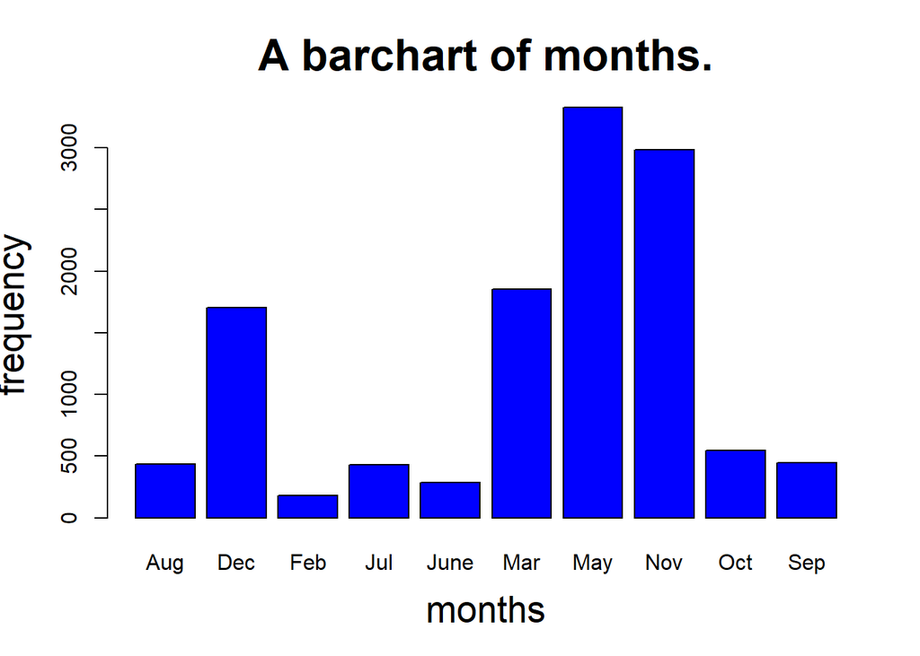

```r
#Bar chart
options(repr.plot.width = 10, repr.plot.height = 10)
barplot(c(month.freq), main="A barchart of months.",
        xlab="months",
        ylab="frequency",
        cex.main=2, cex.lab=1.7,cex.sub=1.2,
        col=c("blue"))
```

```r
# Bar chart of Operating systems
os.freq <- table(kp$OperatingSystems)
sort(os.freq, decreasing = TRUE)[1:5]
```

```
##
##    2    1    3    4    8
## 6536 2548 2530  478   75
```

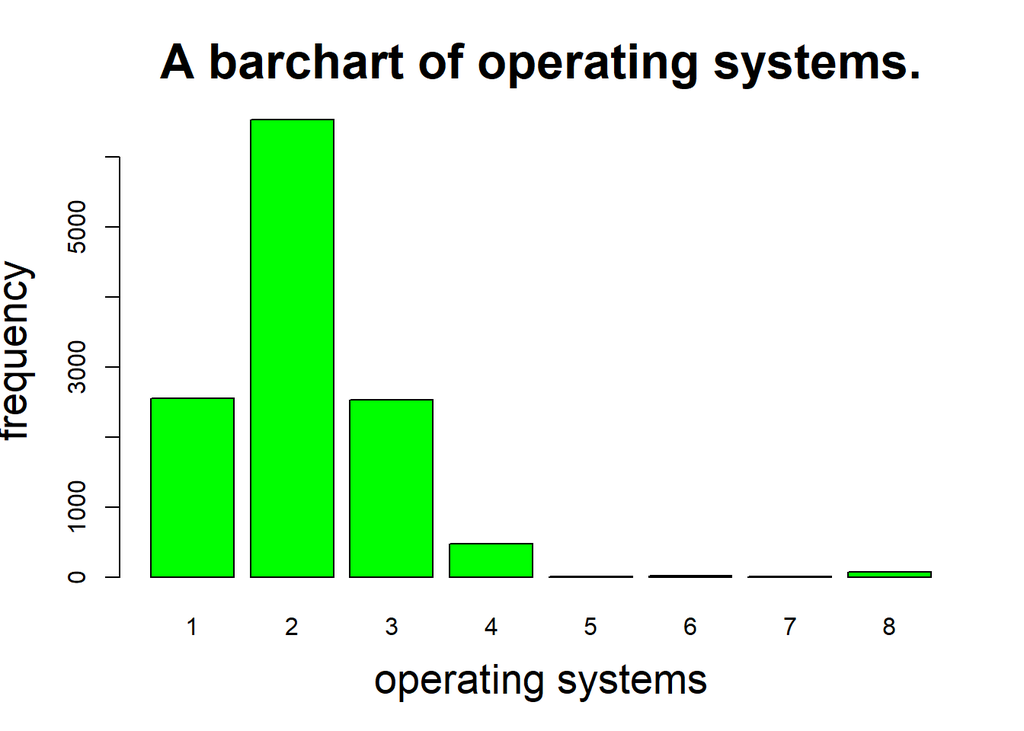

```r
options(repr.plot.width = 10, repr.plot.height = 10)
barplot(c(os.freq), main="A barchart of operating systems.",
        xlab="operating systems",
        ylab="frequency",
        cex.main=2, cex.lab=1.7,cex.sub=1.2,
        col=c("green"))
```

```r
# Bar chart for the region
region.freq <- table(kp$Region)
sort(region.freq, decreasing = TRUE)[1:5]
```

```
##
##    1    3    4    2    6
## 4711 2382 1168 1127  800
```

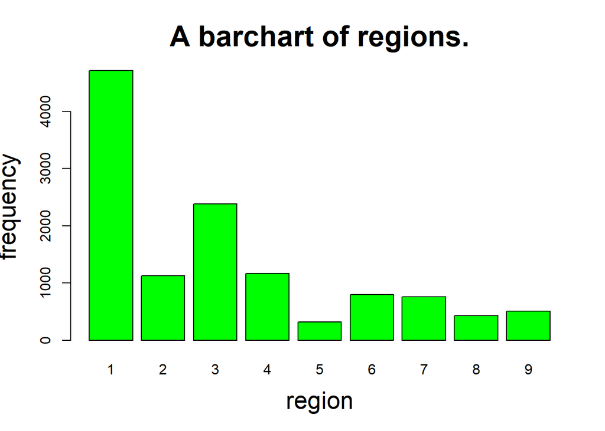

```r
options(repr.plot.width = 10, repr.plot.height = 10)
barplot(c(region.freq), main="A barchart of regions.",
        xlab="region",
        ylab="frequency",
        cex.main=2, cex.lab=1.7,cex.sub=1.2,
        col=c("green"))
```

```r
#frequency table of visitor type
visitor.freq <- table(kp$VisitorType)
sort(visitor.freq, decreasing = TRUE)[1:5]
```

```
##
## Returning_Visitor       New_Visitor             Other              <NA>
##             10425              1693                81
##              <NA>
##
```

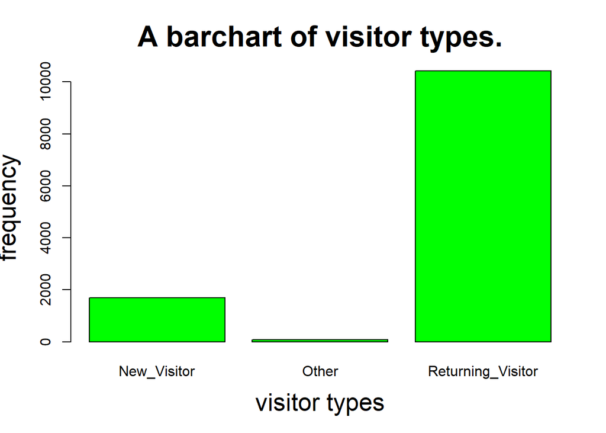

```r
options(repr.plot.width = 10, repr.plot.height = 10)
barplot(c(visitor.freq), main="A barchart of visitor types.",
        xlab="visitor types",
        ylab="frequency",
        cex.main=2, cex.lab=1.7,cex.sub=1.2,
        col=c("green"))
```

```r
#frequency table of weekend
weekend.freq <- table(kp$Weekend)
sort(weekend.freq, decreasing = TRUE)[1:5]
```

```
##
## FALSE  TRUE  <NA>  <NA>  <NA>
##  9343  2856
```

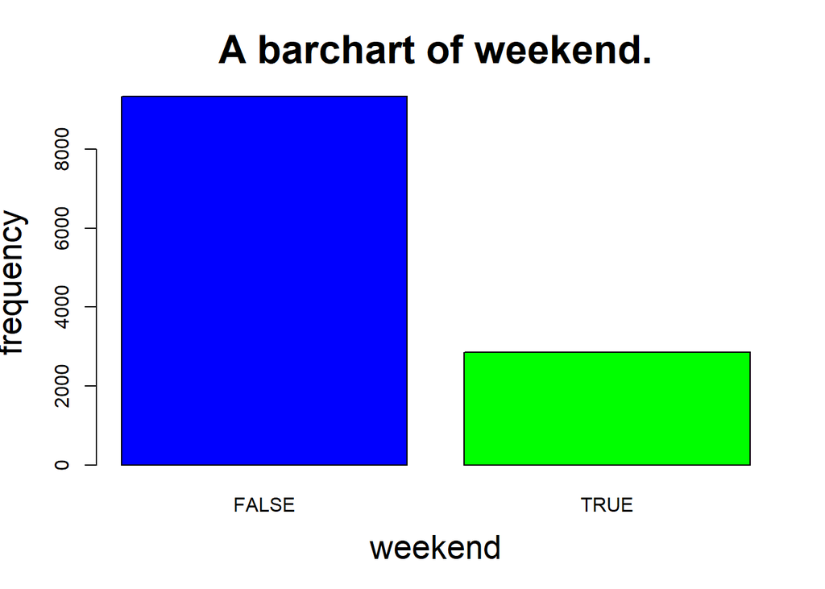

```r
options(repr.plot.width = 10, repr.plot.height = 10)
barplot(c(weekend.freq), main="A barchart of weekend.",
        xlab="weekend",
        ylab="frequency",
        cex.main=2, cex.lab=1.7,cex.sub=1.2,
        col=c("blue", "green"))
```

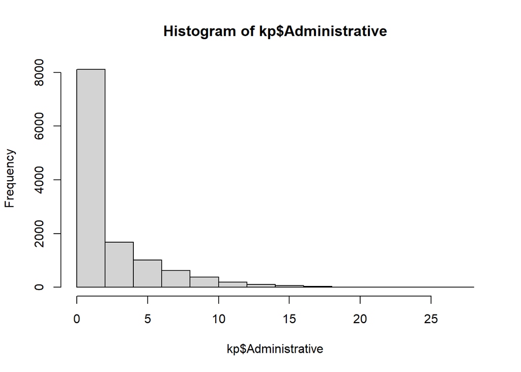

```r
#Admin histogram.
hist(kp$Administrative)
```

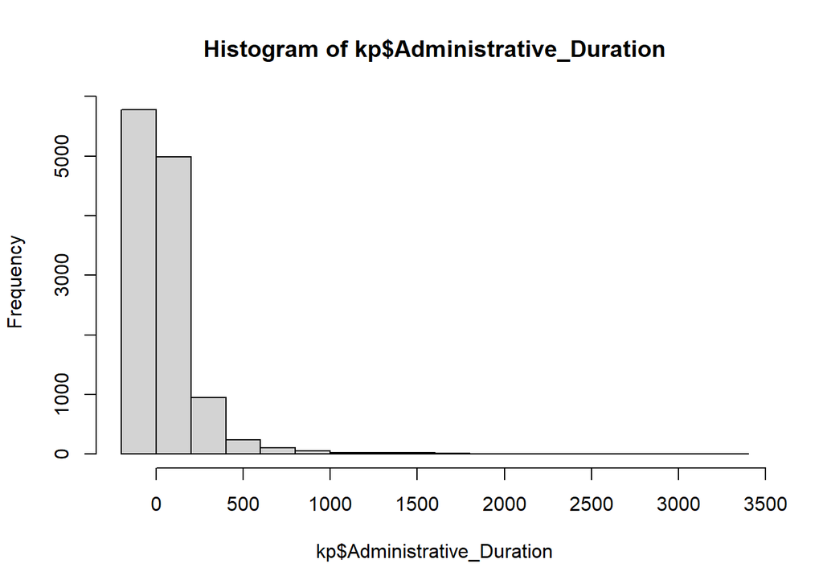

```r
#  Histogram of administrative duration
hist(kp$Administrative_Duration)
```

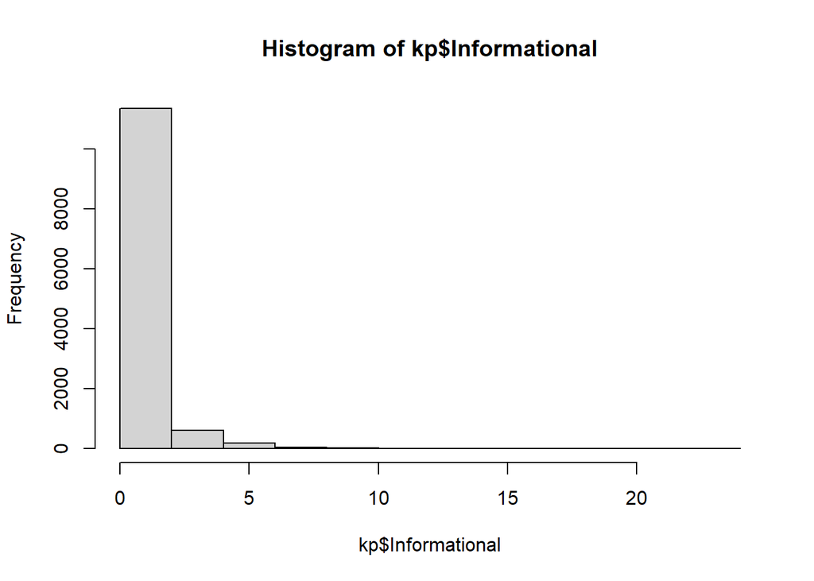

```r
# Histogram of informational
hist(kp$Informational)
```

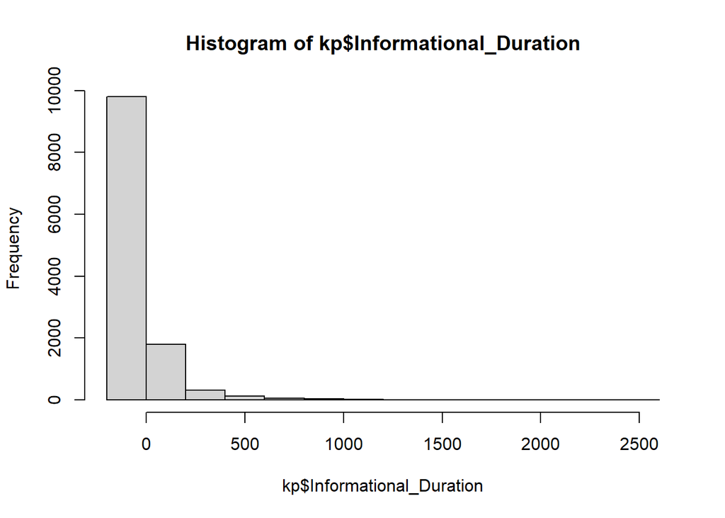

```r
# Histogram of informational duration
hist(kp$Informational_Duration)
```

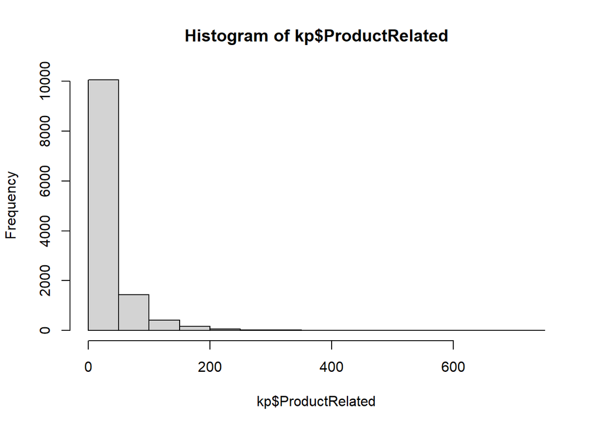

```r
# Histogram of product related
hist(kp$ProductRelated)
```

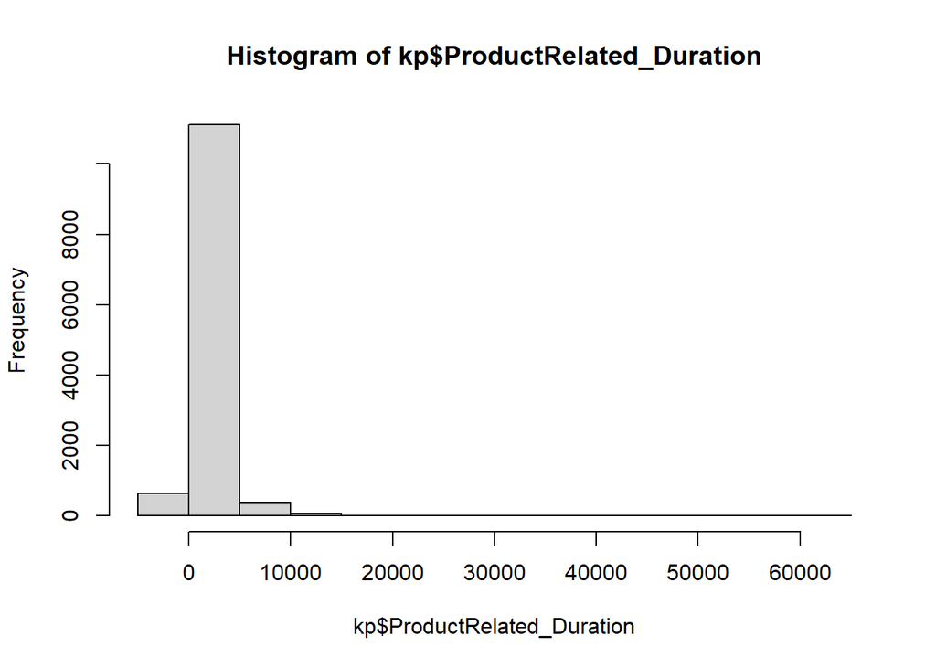

```r
# Histogram of product related duration
hist(kp$ProductRelated_Duration)
```

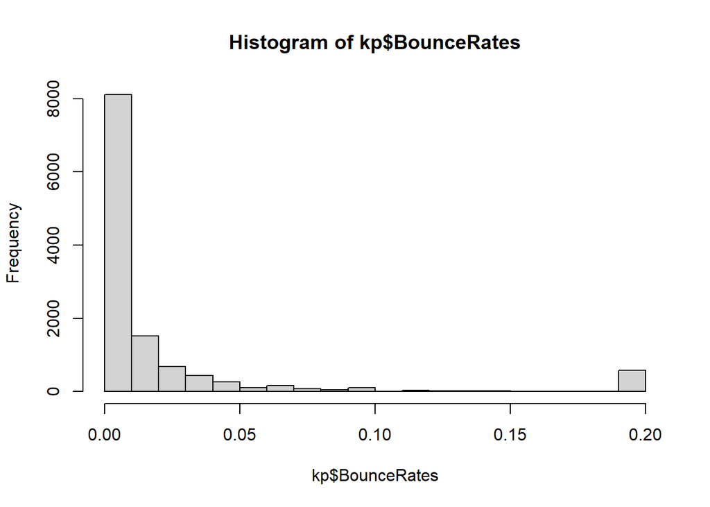

```r
# Bounce rates histogram
hist(kp$BounceRates)
```

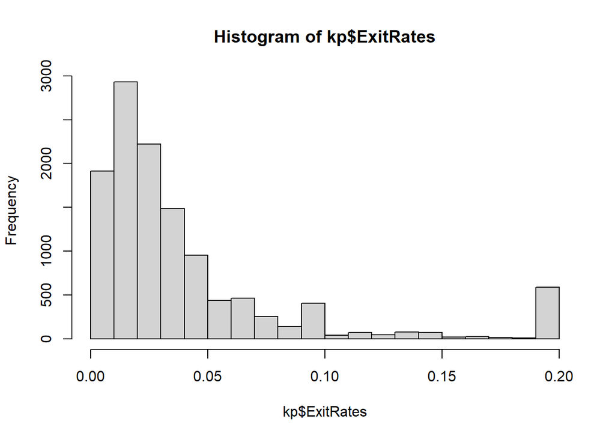

```r
# Exit rates histogram
hist(kp$ExitRates)
```

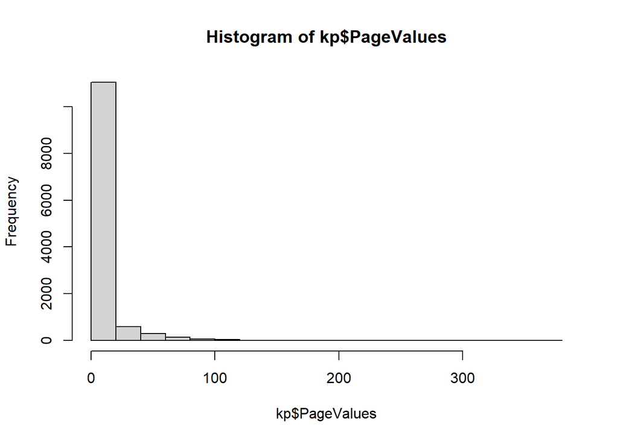

```r
# page values histogram
hist(kp$PageValues)
```

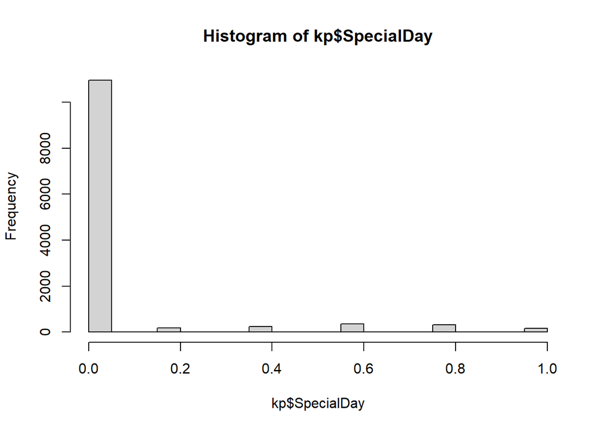

```r
# special day histogram
hist(kp$SpecialDay)
```

## Observations 1. The months of May, November, March and December have the most web page visits. 2. Type 2 operating systenm is the most common amongst the users. 3. Most users preferred the type 2 Browser. 4. Region 1 registered the highest number of individuals in the data 5. The website looks to be frequented by previous users of the site as compared to the pther visitors. 6. Most web page visits were made during the weekday.

```r
#finding the covariance
cov <- cov(kp[,unlist(lapply(kp, is.numeric))])
cov
```

```
##                         Administrative Administrative_Duration Informational
## Administrative             11.09456996              355.034186   1.594806280
## Administrative_Duration   355.03418646            31516.250360  68.273361883
## Informational               1.59480628               68.273362   1.627709681
## Informational_Duration    120.04936778             5956.517671 111.656022657
## ProductRelated             63.61170357             2270.731540  21.202182071
## ProductRelated_Duration  2372.71642208           120492.067559 945.703033133
## BounceRates                -0.03231259               -1.106938  -0.006343127
## ExitRates                  -0.04794942               -1.658656  -0.009414909
## PageValues                  6.02328225              219.168388   1.128072018
## SpecialDay                 -0.06457297               -2.649741  -0.012580917
## OperatingSystems           -0.02023465               -1.225443  -0.011138556
## Browser                    -0.14679306               -4.808302  -0.084604074
## Region                     -0.05811216               -2.867667  -0.093415216
## TrafficType                -0.46527507              -10.747278  -0.180277021
##                         Informational_Duration ProductRelated
## Administrative                     120.0493678     63.6117036
## Administrative_Duration           5956.5176708   2270.7315396
## Informational                      111.6560227     21.2021821
## Informational_Duration           20010.5068642   1760.6514935
## ProductRelated                    1760.6514935   1989.2412959
## ProductRelated_Duration          94127.8699847  73668.6330189
## BounceRates                         -0.4506041     -0.3918681
## ExitRates                           -0.6733911     -0.5902590
## PageValues                          79.3484334     45.0324519
## SpecialDay                          -0.8840522     -0.2309712
## OperatingSystems                    -1.2509309      0.1654644
## Browser                             -4.7449864     -1.0456925
## Region                              -9.4885165     -4.2974501
## TrafficType                        -14.2946907     -7.9424649
##                         ProductRelated_Duration   BounceRates     ExitRates
## Administrative                       2372.71642 -3.231259e-02 -4.794942e-02
## Administrative_Duration            120492.06756 -1.106938e+00 -1.658656e+00
## Informational                         945.70303 -6.343127e-03 -9.414909e-03
## Informational_Duration              94127.86998 -4.506041e-01 -6.733911e-01
## ProductRelated                      73668.63302 -3.918681e-01 -5.902590e-01
## ProductRelated_Duration           3686121.49674 -1.520023e+01 -2.178350e+01
## BounceRates                           -15.20023  2.061387e-03  1.896814e-03
## ExitRates                             -21.78350  1.896814e-03  2.138800e-03
## PageValues                           1821.19283 -9.825801e-02 -1.497697e-01
```

[output cut: 20 more lines]

```
##                               Browser        Region   TrafficType
## Administrative          -1.467931e-01 -5.811216e-02   -0.46527507
## Administrative_Duration -4.808302e+00 -2.867667e+00  -10.74727804
## Informational           -8.460407e-02 -9.341522e-02   -0.18027702
## Informational_Duration  -4.744986e+00 -9.488517e+00  -14.29469072
## ProductRelated          -1.045692e+00 -4.297450e+00   -7.94246492
## ProductRelated_Duration -2.574253e+01 -1.608036e+02 -289.18113001
## BounceRates             -1.244059e-03  1.561995e-04    0.01626348
## ExitRates               -2.820677e-04 -2.041634e-04    0.01622937
## PageValues               1.463173e+00  4.747272e-01    0.91686751
## SpecialDay               1.184051e-03 -7.893768e-03    0.04236803
## OperatingSystems         3.292913e-01  1.567845e-01    0.66607948
## Browser                  2.926075e+00  3.776251e-01    0.70676249
## Region                   3.776251e-01  5.771712e+00    0.41027258
## TrafficType              7.067625e-01  4.102726e-01   16.12675171
```